# Fisseha Berhane, PhD

## Support Vector Machines

There are a couple of options to work with support vector machines for regression. The details can be found from the [caret](http://topepo.github.io/caret/Support_Vector_Machines.html) website.

Here, let's use support vector machines with radial basis function kernel.

```
loess r-squared variable importance

         Overall
CFC.12   0.64706
CO2      0.64428
N2O      0.62275
Aerosols 0.57937
CH4      0.54393
CFC.11   0.49591
TSI      0.14404
MEI      0.08436
```

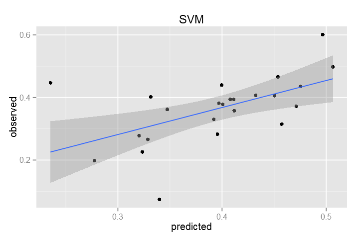

```
Length  Class   Mode
     1   ksvm     S4
```

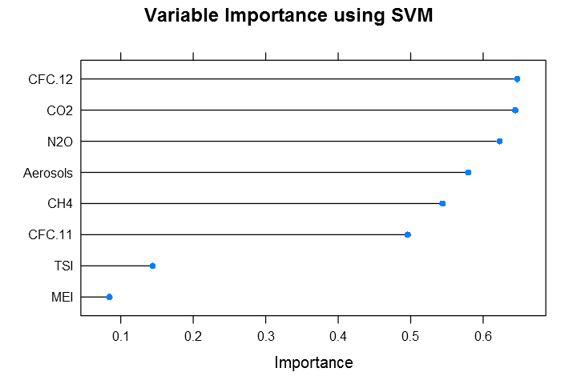

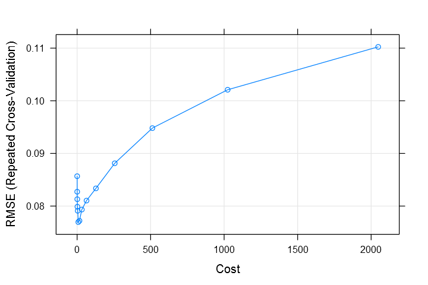

```r
control <- trainControl(method="repeatedcv", number=10, repeats=5)

my_svm <- train(training[,3:10], training[,11],
method = "svmRadial",
preProc = c("center", "scale"),
tuneLength = 14,
trControl = control)

# predict using the test data

pred<-predict(my_svm,testingX)

my_data=as.data.frame(cbind(predicted=pred,observed=testingY))

ggplot(my_data,aes(predicted,observed))+geom_point()+geom_smooth(method=lm)+ggtitle('SVM')

# Print, plot variable importance

print(varImp(my_svm, scale = FALSE))

plot(varImp(my_svm, scale = FALSE), main="Variable Importance using SVM")

summary(my_svm)

plot(my_svm)
```

## CART

```
rpart variable importance

         Overall
CFC.12     4.342
CFC.11     4.070
N2O        3.617
Aerosols   3.332
MEI        2.888
CO2        2.693
TSI        2.245
CH4        1.274
```

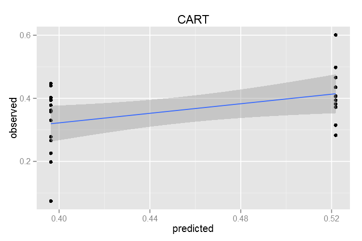

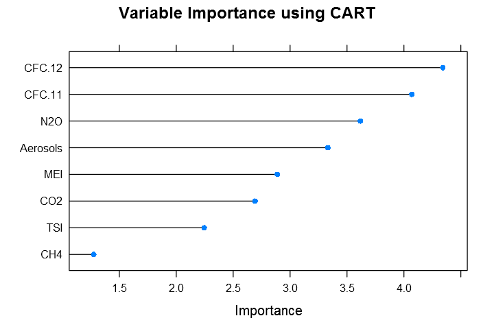

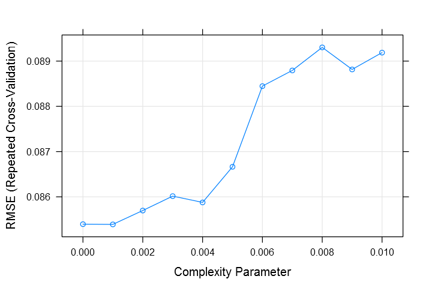

```r
control <- trainControl(method="repeatedcv", number=10, repeats=5)

cp.grid = expand.grid( .cp = (0:10)*0.001)

my_cart <- train(training[,3:10], training[,11],
method = "rpart",
preProc = c("center", "scale"),

tuneGrid = cp.grid,

trControl = control)

# predict using the test data

pred<-predict(my_cart,testingX)

my_data=as.data.frame(cbind(predicted=pred,observed=testingY))

ggplot(my_data,aes(predicted,observed))+geom_point()+geom_smooth(method=lm)+ggtitle('CART')

# Print, Plot variable importance

print(varImp(my_cart, scale = FALSE))

plot(varImp(my_cart, scale = FALSE),main="Variable Importance using CART")

plot(my_cart)
```

## Bagged CART

```
treebag variable importance

         Overall
CFC.12    2.4243
N2O       2.1417
CFC.11    2.0582
Aerosols  2.0095
CO2       1.5809
MEI       1.3792
CH4       1.0922
TSI       0.9845
```

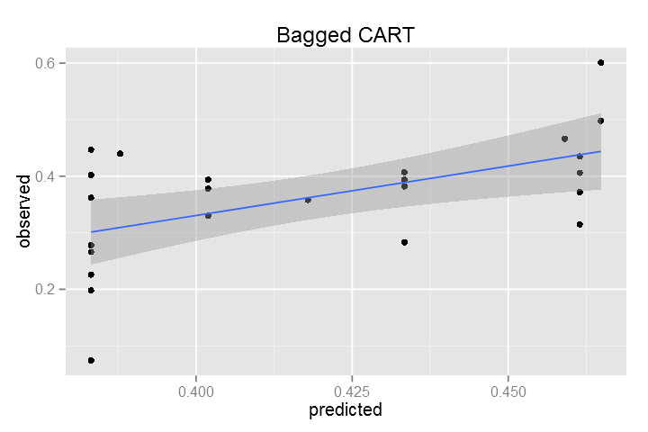

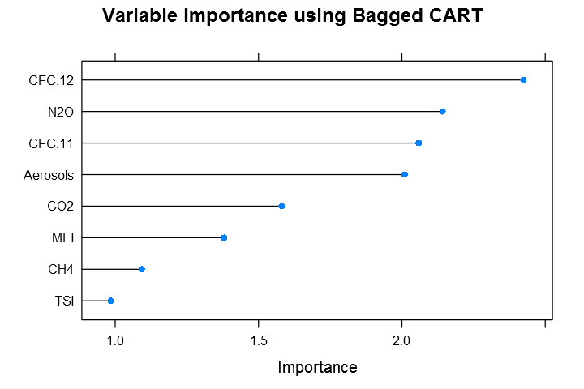

```r
control <- trainControl(method="repeatedcv", number=10, repeats=5)


my_bagged_cart <- train(training[,3:10], training[,11],
method = "treebag",
preProc = c("center", "scale"),
trControl = control)

pred<-predict(my_bagged_cart,testingX)

my_data=as.data.frame(cbind(predicted=pred,observed=testingY))

ggplot(my_data,aes(predicted,observed))+geom_point()+geom_smooth(method=lm)+ggtitle('Bagged CART')

# Print, Plot variable importance

print(varImp(my_bagged_cart, scale = FALSE))

plot(varImp(my_bagged_cart, scale = FALSE),main="Variable Importance using Bagged CART")
```

## Random Forest

```
rf variable importance

         Overall
CFC.11     23.86
MEI        21.95
CFC.12     21.68
Aerosols   17.95
TSI        17.49
N2O        17.45
CO2        13.03
CH4        11.85
```

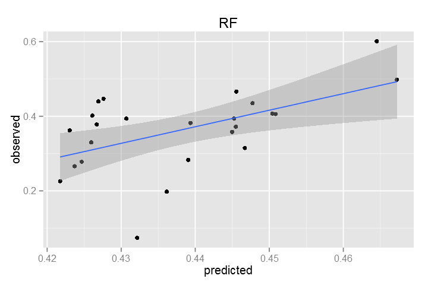

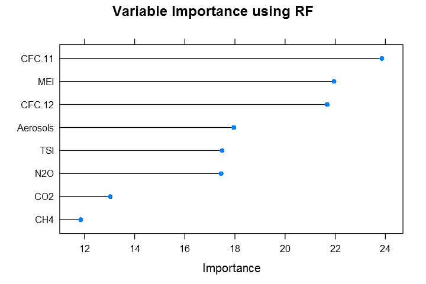

```r
control <- trainControl(method="repeatedcv", number=10, repeats=5)

my_rf <- train(training[,3:10], training[,11],
method = "rf", ntrees = 1000,importance = TRUE,
preProc = c("center", "scale"),

trControl = control)

# Predict using the test data

pred<-predict(my_rf,testingX)

my_data=as.data.frame(cbind(predicted=pred,observed=testingY))

ggplot(my_data,aes(predicted,observed))+geom_point()+geom_smooth(method=lm)+ggtitle('RF')

# Print, Plot variable importance

print(varImp(my_rf, scale = FALSE))

plot(varImp(my_rf, scale = FALSE),main="Variable Importance using RF")
```

## Boosting

```
gbm variable importance

         Overall
CFC.12     81.36
N2O        68.42
Aerosols   33.05
CFC.11     26.64
MEI        26.33
CO2        18.68
TSI        15.08
CH4        10.87
```

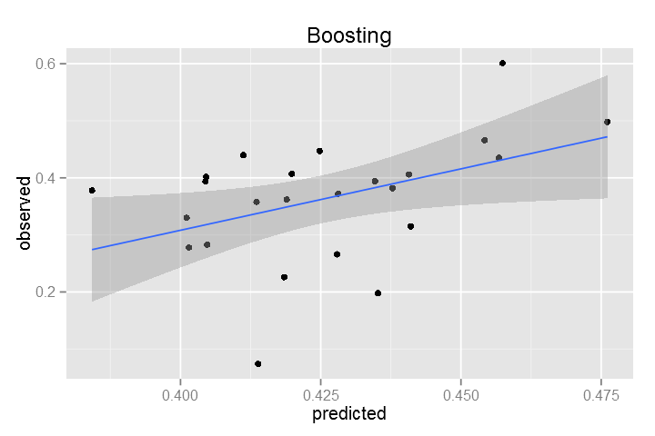

```
Time taken =  29.72348
```

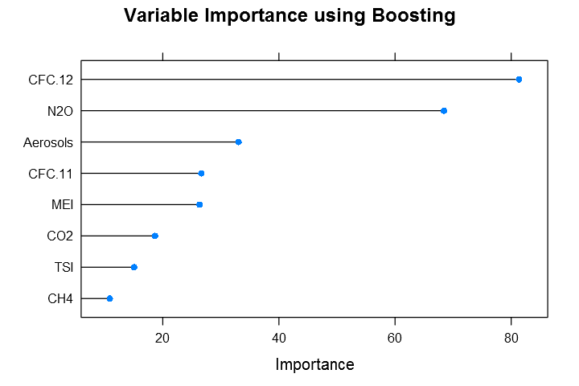

```r
# To tune over interaction depth, number of trees, and shrinkage first define a tuning grid, then train over this grid
start.time <- Sys.time()

gbmGrid <- expand.grid(.interaction.depth = c(2,5,8),
                      .n.trees = c(500, 1000,2000,5000),
                       .shrinkage = c(0.01, 0.1),
                        .n.minobsinnode=c(5,10,15))


control <- trainControl(method="repeatedcv", number=10, repeats=5)

my_boosting <- train(training[,3:10], training[,11],
                         method = "gbm",verbose=F,
                         tuneGrid = gbmGrid,
                         preProc = c("center", "scale"),
            trControl = control)

# Predict using the test data
pred<-predict(my_boosting,testingX)

my_data=as.data.frame(cbind(predicted=pred,observed=testingY))

ggplot(my_data,aes(predicted,observed))+geom_point()+geom_smooth(method=lm)+ggtitle('Boosting')

# Print, Plot variable importance

print(varImp(my_boosting, scale = FALSE))

plot(varImp(my_boosting, scale = FALSE),main="Variable Importance using Boosting")

end.time <- Sys.time()
time.taken <- end.time - start.time
cat("Time taken = ",time.taken)
```

We can use the caret package to compare the perfomance of the machine learning models we built using the train function from the caret library.

```
Call:
summary.resamples(object = results)

Models: GLM, sGLM, PLS, Ridge_Regr, enet, Lasso, nnet, boosting, rf, SVM
Number of resamples: 50

RMSE
              Min. 1st Qu.  Median    Mean 3rd Qu.    Max. NA's
GLM        0.06037 0.08500 0.09360 0.09171 0.09745 0.12920    0
sGLM       0.06588 0.08414 0.09320 0.09232 0.09975 0.12210    0
PLS        0.06581 0.08373 0.09040 0.09226 0.10150 0.12050    0
Ridge_Regr 0.06059 0.08055 0.08920 0.09177 0.10350 0.12950    0
enet       0.06104 0.08012 0.08919 0.09174 0.10350 0.13000    0
Lasso      0.06104 0.08012 0.08919 0.09174 0.10350 0.13000    0
nnet       0.05433 0.06593 0.07808 0.07769 0.09039 0.10550    0
boosting   0.05134 0.06085 0.06770 0.06961 0.07702 0.09617    0
rf         0.03958 0.06273 0.06881 0.06834 0.07444 0.09138    0
SVM        0.04183 0.06762 0.07719 0.07697 0.08998 0.10480    0

Rsquared
             Min. 1st Qu. Median   Mean 3rd Qu.   Max. NA's
GLM        0.5911  0.7124 0.7513 0.7508  0.7855 0.8891    0
sGLM       0.5208  0.7119 0.7511 0.7477  0.7993 0.8653    0
PLS        0.6279  0.7198 0.7550 0.7523  0.7983 0.8744    0
Ridge_Regr 0.5764  0.6980 0.7695 0.7523  0.8123 0.8669    0
enet       0.5723  0.6982 0.7708 0.7526  0.8131 0.8636    0
Lasso      0.5723  0.6982 0.7708 0.7526  0.8131 0.8636    0
nnet       0.7007  0.7685 0.8340 0.8215  0.8726 0.9181    0
boosting   0.7425  0.8336 0.8541 0.8570  0.8928 0.9315    0
rf         0.7598  0.8391 0.8685 0.8651  0.8888 0.9499    0
SVM        0.7014  0.7881 0.8186 0.8242  0.8640 0.9550    0
```

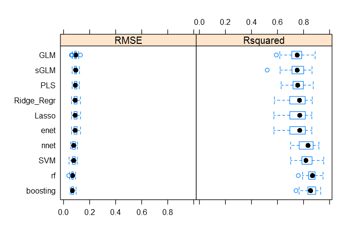

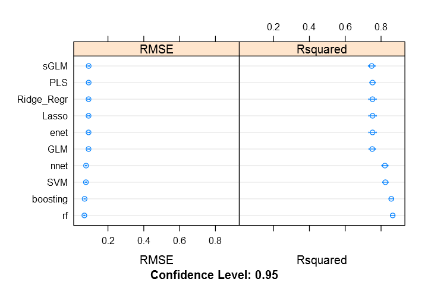

```r
# collect resamples

results <- resamples(list(GLM=my_glm,sGLM=my_stepglm,PLS=my_tunedpls, Ridge_Regr=my_ridgeReg,
                          enet=my_enet ,Lasso=my_lasso, nnet=my_avnnet,
                          boosting=my_boosting, rf=my_rf, SVM=my_svm))

# summarize the distributions
summary(results)
# boxplots of results
bwplot(results)
# dot plots of results
dotplot(results)
```

Then, we can use different tests to assess if the performance of one model is significantly better than the others.

## Conclusion

Generally, all considered models have similar performances but boosting and random forest seem to be slightly better. Of course, to decide if the ensemble tree techniques are significantly better than the other models in this application, hypothesis tests have to be implemented.

[comments powered by Disqus](http://disqus.com)